# Oracle Operations POC using UCI Bank Marketing Dataset

## XGBoost with stratified 10-fold cross validation using caret

```r
set.seed(2004)
grid_default <- expand.grid(
  nrounds = 100,
  max_depth = 6,
  eta = 0.3,
  gamma = 0,
  colsample_bytree = 1,
  min_child_weight = 1,
  subsample = 1
)

folds=10
cvIndex <- createFolds(factor(balanced_trainset$response), folds, returnTrain = T) #stratified k fold
train_control <- trainControl(
  index = cvIndex,
  number = folds,
  method = "cv",
  verboseIter = FALSE, # no training log
  allowParallel = TRUE # FALSE for reproducible results
)

#install.packages('e1071', dependencies=TRUE)

xgb_base <- train(
  response~., data=balanced_trainset,
  trControl = train_control,
  tuneGrid = grid_default,
  method = "xgbTree",
  verbose = TRUE
)

print(xgb_base)
```

```
eXtreme Gradient Boosting

18704 samples
   36 predictor
    2 classes: '0', '1'

No pre-processing
Resampling: Cross-Validated (10 fold)
Summary of sample sizes: 16834, 16834, 16833, 16834, 16833, 16833, ...
Resampling results:

  Accuracy   Kappa
  0.9315122  0.8597923

Tuning parameter 'nrounds' was held constant at a value of 100
Tuning parameter 'max_depth' was held
 of 1
Tuning parameter 'min_child_weight' was held constant at a value of 1
Tuning parameter 'subsample'
 was held constant at a value of 1
```

Confusion Matrix and Accuracies

```r
xgb_base.predict.train <- predict(xgb_base, newdata = balanced_trainset, type = "raw")
results <- data.frame(balanced_trainset, xgb_base.predict.train)
traintable <- table(xgb_base.predict.train, balanced_trainset$response)
traintable
```

```
xgb_base.predict.train     0     1
                     0 10506   243
                     1   182  7773
```

```r
round(prop.table(traintable),2)
```

```
xgb_base.predict.train    0    1
                     0 0.56 0.01
                     1 0.01 0.42
```

```r
print("Train Accuracy:")
```

```
[1] "Train Accuracy:"
```

```r
mean(results$xgb_base.predict.train == balanced_trainset$response)
```

```
[1] 0.9772776
```

```r
xgb_base.predict.test <- predict(xgb_base, newdata = balanced_testset, type = "raw")
results <- data.frame(balanced_testset, xgb_base.predict.test)
testtable <- table(xgb_base.predict.test, balanced_testset$response)
testtable
```

```
xgb_base.predict.test    0    1
                    0 3273  297
                    1  287 2373
```

```r
round(prop.table(testtable),2)
```

```
xgb_base.predict.test    0    1
                    0 0.53 0.05
                    1 0.05 0.38
```

```r
print("Test Accuracy:")
```

```
[1] "Test Accuracy:"
```

```r
mean(results$xgb_base.predict.test == balanced_testset$response)
```

```
[1] 0.90626
```

### Feature Importance using XGBoost

```r
y = balanced_trainset$response
X = balanced_trainset[,!"response",with=FALSE]
xgb <- xgboost(data = data.matrix(X[,-1]),
 label = y,
  nrounds = 100,
  max_depth = 6,
  eta = 0.3,
  gamma = 0,
  colsample_bytree = 1,
  min_child_weight = 1,
  subsample = 1,
 eval_metric = "merror",
 objective = "multi:softprob",
 num_class = 12,
 nthread = 3
)
```

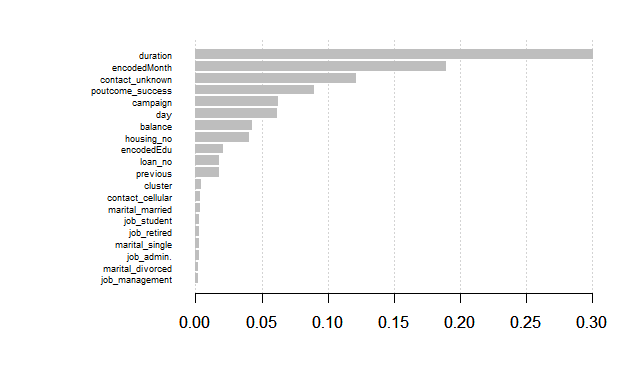

```r
# Get the feature real names
names <- dimnames(data.matrix(X[,-1]))[[2]]
# Compute feature importance matrix
importance_matrix <- xgb.importance(names, model = xgb)
# Graph
xgb.plot.importance(importance_matrix[1:20,])
```

```r
selected = importance_matrix[importance_matrix$Gain >= 0.01, Feature]
balanced_trainset1= balanced_trainset[,..selected]
balanced_trainset1=balanced_trainset1[,response:=balanced_trainset$response]
head(balanced_trainset1)
```

| duration | encodedMonth | contact_unknown | poutcome_success | campaign | day | balance | housing_no | encodedEdu | loan_no | previous | response |
| --- | --- | --- | --- | --- | --- | --- | --- | --- | --- | --- | --- |
| 280 | 2 | 0 | 0 | 2 | 3 | 483 | 0 | 3 | 1 | 0 | 0 |
| 109 | 6 | 1 | 0 | 1 | 4 | -565 | 0 | 2 | 1 | 0 | 0 |
| 494 | 3 | 0 | 0 | 1 | 31 | 7336 | 1 | 2 | 1 | 0 | 0 |
| 39 | 5 | 0 | 1 | 1 | 13 | 1905 | 0 | 2 | 1 | 2 | 0 |
| 327 | 6 | 0 | 0 | 1 | 2 | 387 | 1 | 3 | 1 | 0 | 0 |
| 153 | 2 | 0 | 0 | 1 | 2 | 1074 | 1 | 2 | 1 | 0 | 0 |

```r
balanced_testset1= balanced_testset[,..selected]
balanced_testset1=balanced_testset1[,response:=balanced_testset$response]
```

### XGBoost model with top features (gain >= 0.01)

```r
xgb_1 <- train(
  response~., data=balanced_trainset1,
  trControl = train_control,
  tuneGrid = grid_default,
  method = "xgbTree",
  verbose = TRUE
)

print(xgb_1)
```

```
eXtreme Gradient Boosting

18704 samples
   11 predictor
    2 classes: '0', '1'

No pre-processing
Resampling: Cross-Validated (10 fold)
Summary of sample sizes: 16834, 16834, 16833, 16834, 16833, 16833, ...
Resampling results:

  Accuracy   Kappa
  0.9275554  0.8517398

Tuning parameter 'nrounds' was held constant at a value of 100
Tuning parameter 'max_depth' was held
 of 1
Tuning parameter 'min_child_weight' was held constant at a value of 1
Tuning parameter 'subsample'
 was held constant at a value of 1
```

Confusion Matrix and Accuracies

```r
xgb_1.predict.train <- predict(xgb_1, newdata = balanced_trainset1, type = "raw")
results <- data.frame(balanced_trainset1, xgb_1.predict.train)
traintable <- table(xgb_1.predict.train, balanced_trainset1$response)
traintable
```

```
xgb_1.predict.train     0     1
                  0 10466   306
                  1   222  7710
```

```r
round(prop.table(traintable),2)
```

```
xgb_1.predict.train    0    1
                  0 0.56 0.02
                  1 0.01 0.41
```

```r
print("Train Accuracy:")
```

```
[1] "Train Accuracy:"
```

```r
mean(results$xgb_1.predict.train == balanced_trainset1$response)
```

```
[1] 0.9717707
```

```r
xgb_1.predict.test <- predict(xgb_1, newdata = balanced_testset1, type = "raw")
results <- data.frame(balanced_testset1, xgb_1.predict.test)
testtable <- table(xgb_1.predict.test, balanced_testset1$response)
testtable
```

```
xgb_1.predict.test    0    1
                 0 3274  282
                 1  286 2388
```

```r
round(prop.table(testtable),2)
```

```
xgb_1.predict.test    0    1
                 0 0.53 0.05
                 1 0.05 0.38
```

```r
print("Test Accuracy:")
```

```
[1] "Test Accuracy:"
```

```r
mean(results$xgb_1.predict.test == balanced_testset1$response)
```

```
[1] 0.9088283
```

## Optimised XGBoost using Boruta Feature Selection

```r
boruta <- Boruta(response ~ ., data = balanced_testset, doTrace = 2, maxRuns=11)
```

```
 1. run of importance source...
 2. run of importance source...
 3. run of importance source...
 4. run of importance source...
 5. run of importance source...
 6. run of importance source...
 7. run of importance source...
 8. run of importance source...
 9. run of importance source...
 10. run of importance source...
```

```r
print(boruta)
```

```
Boruta performed 10 iterations in 1.00704 mins.
 No attributes deemed important.
 No attributes deemed unimportant.
 36 tentative attributes left: `job_blue-collar`, `job_self-employed`, age, balance, campaign and
31 more;
```

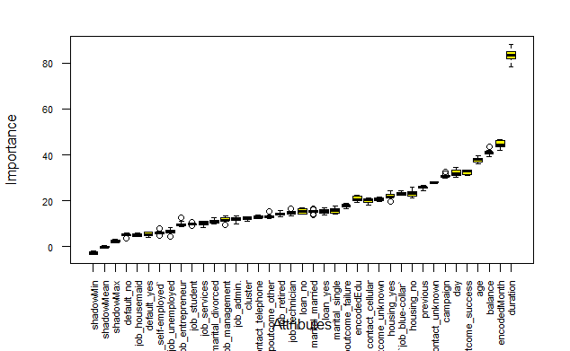

```r
plot(boruta, las = 2, cex.axis = 0.7)
```

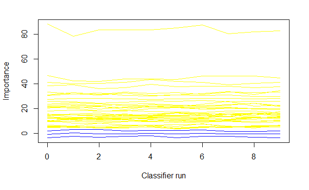

```r
plotImpHistory(boruta)
```

```r
bor <- TentativeRoughFix(boruta)
print(bor)
```

```
Boruta performed 10 iterations in 1.00704 mins.
Tentatives roughfixed over the last 10 iterations.
 36 attributes confirmed important: `job_blue-collar`, `job_self-employed`, age, balance, campaign
and 31 more;
 No attributes deemed unimportant.
```

```r
attStats(bor)
```

|  | meanImp | medianImp | minImp | maxImp | normHits | decision |
| --- | --- | --- | --- | --- | --- | --- |
| age | 37.936962 | 37.916638 | 36.152636 | 39.511847 | 1 | Confirmed |
| balance | 41.070049 | 41.101969 | 39.428412 | 43.564985 | 1 | Confirmed |
| day | 32.186573 | 31.902420 | 30.297987 | 34.505386 | 1 | Confirmed |
| duration | 83.387750 | 83.389274 | 78.344986 | 88.043079 | 1 | Confirmed |
| campaign | 30.911873 | 30.751989 | 29.842027 | 32.648530 | 1 | Confirmed |
| previous | 25.780285 | 25.953641 | 24.501695 | 26.619732 | 1 | Confirmed |
| encodedEdu | 20.786443 | 20.338802 | 19.270777 | 22.460750 | 1 | Confirmed |
| encodedMonth | 44.621877 | 44.480961 | 42.113500 | 46.779098 | 1 | Confirmed |
| job_admin. | 11.950030 | 12.002255 | 9.898197 | 13.396216 | 1 | Confirmed |
| `job_blue-collar` | 23.168822 | 23.000469 | 22.302040 | 24.342383 | 1 | Confirmed |

[output cut: 26 more lines]

```r
getSelectedAttributes(bor, withTentative = F)
```

```
 [1] "age"                 "balance"             "day"                 "duration"
 [5] "campaign"            "previous"            "encodedEdu"          "encodedMonth"
 [9] "job_admin."          "`job_blue-collar`"   "job_entrepreneur"    "job_housemaid"
[13] "job_management"      "job_retired"         "`job_self-employed`" "job_services"
[17] "job_student"         "job_technician"      "job_unemployed"      "marital_divorced"
[21] "marital_married"     "marital_single"      "housing_no"          "housing_yes"
[25] "default_no"          "default_yes"         "loan_no"             "loan_yes"
[29] "contact_cellular"    "contact_telephone"   "contact_unknown"     "poutcome_failure"
[33] "poutcome_other"      "poutcome_success"    "poutcome_unknown"    "cluster"
```

Drop less important variables

```r
boruta_data <- copy(finalClusteredData)
boruta_data[, job_admin. := NULL]
boruta_data[, job_housemaid := NULL]
boruta_data[, `job_self-employed` := NULL]
boruta_data[, job_technician := NULL]
boruta_data[, job_unemployed := NULL]
boruta_data[, marital_divorced := NULL]
boruta_data[, default_no := NULL]
boruta_data[, default_yes := NULL]
```

Train and Test Split

```r
boruta_train <- sample.split(Y = boruta_data$response, SplitRatio = 0.75)
boruta_trainset <- subset(boruta_data, boruta_train == T)
boruta_testset <- subset(boruta_data, boruta_train == F)
```

Balance imbalanced dataset using SMOTE

```r
set.seed(2004)
# Count of unique value in the target variable
as.data.frame(table(boruta_trainset$response))
```

| Var1 | Freq |
| --- | --- |
| 0 | 26644 |
| 1 | 2672 |

```r
# Convert the response var from num to factor
boruta_trainset$response = as.factor(boruta_trainset$response)
## Smote : Synthetic Minority Oversampling Technique To Handle Response Imbalancy In Binary Classification
boruta_balanced_trainset = SMOTE(response~., boruta_trainset, perc.over = 200, k = 5, perc.under = 200, learner = NULL)

as.data.frame(table(boruta_balanced_trainset$response))
```

| Var1 | Freq |
| --- | --- |
| 0 | 10688 |
| 1 | 8016 |

```r
# Convert the response var from num to factor
boruta_testset$response = as.factor(boruta_testset$response)
## Smote : Synthetic Minority Oversampling Technique To Handle Response Imbalancy In Binary Classification
boruta_balanced_testset = SMOTE(response~., boruta_testset, perc.over = 200, k = 5, perc.under = 200, learner = NULL)

as.data.frame(table(boruta_balanced_testset$response))
```

| Var1 | Freq |
| --- | --- |
| 0 | 3560 |
| 1 | 2670 |

### Optimised XGBoost model with features selected by Boruta

```r
xgb_boruta <- train(
  response~., data=boruta_balanced_trainset,
  trControl = train_control,
  tuneGrid = grid_default,
  method = "xgbTree",
  verbose = TRUE
)
```

Confusion Matrix and Accuracies

```r
xgb_boruta.predict.train <- predict(xgb_boruta, newdata = boruta_balanced_trainset, type = "raw")
boruta.train.results <- data.frame(boruta_balanced_trainset, xgb_boruta.predict.train)
boruta_traintable <- table(xgb_boruta.predict.train, boruta_balanced_trainset$response)
boruta_traintable
```

```
xgb_boruta.predict.train     0     1
                       0 10499   304
                       1   189  7712
```

```r
round(prop.table(boruta_traintable),2)
```

```
xgb_boruta.predict.train    0    1
                       0 0.56 0.02
                       1 0.01 0.41
```

```r
print("Train Accuracy:")
```

```
[1] "Train Accuracy:"
```

```r
mean(boruta.train.results$xgb_boruta.predict.train == boruta_balanced_trainset$response)
```

```
[1] 0.973642
```

```r
xgb_boruta.predict.test <- predict(xgb_boruta, newdata = boruta_balanced_testset, type = "raw")
boruta.test.results <- data.frame(boruta_balanced_testset, xgb_boruta.predict.test)
boruta_testtable <- table(xgb_boruta.predict.test, boruta_balanced_testset$response)
boruta_testtable
```

```
xgb_boruta.predict.test    0    1
                      0 3308  293
                      1  252 2377
```

```r
round(prop.table(boruta_testtable),2)
```

```
xgb_boruta.predict.test    0    1
                      0 0.53 0.05
                      1 0.04 0.38
```

```r
print("Test Accuracy:")
```

```
[1] "Test Accuracy:"
```

```r
mean(boruta.test.results$xgb_boruta.predict.test == boruta_balanced_testset$response)
```

```
[1] 0.9125201
```

# Optimising model by using data from other business departments

## Combine Operations and HR data

```r
finalWithHR = copy(boruta_data)
set.seed(1)
finalWithHR$HR_edu = ifelse(boruta_data$response ==1, runif(4289, 2, 5), runif(39922, 1, 5))
finalWithHR$HR_edu=as.integer(finalWithHR$HR_edu)
```

Train and Test Split

```r
# Generate a random number sequence that can be reproduced to verify results.
set.seed(2004)

train1 <- sample.split(Y = finalWithHR$response, SplitRatio = 0.75)
trainset1 <- subset(finalWithHR, train1 == T)
testset1 <- subset(finalWithHR, train1 == F)
summary(trainset1)
```

```
      age           balance            day           duration        campaign        previous
 Min.   :18.00   Min.   : -8019   Min.   : 1.00   Min.   :  0.0   Min.   :1.000   Min.   :  0.0000
 1st Qu.:33.00   1st Qu.:    71   1st Qu.: 8.00   1st Qu.:103.0   1st Qu.:1.000   1st Qu.:  0.0000
 Median :39.00   Median :   442   Median :16.00   Median :172.0   Median :2.000   Median :  0.0000
 Mean   :40.93   Mean   :  1328   Mean   :15.53   Mean   :208.9   Mean   :2.129   Mean   :  0.6026
 3rd Qu.:48.00   3rd Qu.:  1407   3rd Qu.:21.00   3rd Qu.:283.0   3rd Qu.:3.000   3rd Qu.:  0.0000
 Max.   :95.00   Max.   :102127   Max.   :31.00   Max.   :643.0   Max.   :6.000   Max.   :275.0000
    response         encodedEdu     encodedMonth    job_blue-collar  job_entrepreneur  job_management
 Min.   :0.00000   Min.   :1.000   Min.   : 1.000   Min.   :0.0000   Min.   :0.00000   Min.   :0.000
 1st Qu.:0.00000   1st Qu.:2.000   1st Qu.: 5.000   1st Qu.:0.0000   1st Qu.:0.00000   1st Qu.:0.000
 Median :0.00000   Median :2.000   Median : 6.000   Median :0.0000   Median :0.00000   Median :0.000
 Mean   :0.09114   Mean   :2.138   Mean   : 6.099   Mean   :0.2213   Mean   :0.03142   Mean   :0.207
 3rd Qu.:0.00000   3rd Qu.:3.000   3rd Qu.: 8.000   3rd Qu.:0.0000   3rd Qu.:0.00000   3rd Qu.:0.000
 Max.   :1.00000   Max.   :3.000   Max.   :12.000   Max.   :1.0000   Max.   :1.00000   Max.   :1.000
  job_retired       job_services    job_student      marital_married  marital_single     housing_no
 Min.   :0.00000   Min.   :0.000   Min.   :0.00000   Min.   :0.0000   Min.   :0.0000   Min.   :0.0000
 1st Qu.:0.00000   1st Qu.:0.000   1st Qu.:0.00000   1st Qu.:0.0000   1st Qu.:0.0000   1st Qu.:0.0000
 Median :0.00000   Median :0.000   Median :0.00000   Median :1.0000   Median :0.0000   Median :0.0000
 Mean   :0.05065   Mean   :0.092   Mean   :0.02139   Mean   :0.6017   Mean   :0.2851   Mean   :0.4432
 3rd Qu.:0.00000   3rd Qu.:0.000   3rd Qu.:0.00000   3rd Qu.:1.0000   3rd Qu.:1.0000   3rd Qu.:1.0000
 Max.   :1.00000   Max.   :1.000   Max.   :1.00000   Max.   :1.0000   Max.   :1.0000   Max.   :1.0000
  housing_yes        loan_no          loan_yes      contact_cellular contact_telephone contact_unknown
 Min.   :0.0000   Min.   :0.0000   Min.   :0.0000   Min.   :0.000    Min.   :0.00000   Min.   :0.0000
 1st Qu.:0.0000   1st Qu.:1.0000   1st Qu.:0.0000   1st Qu.:0.000    1st Qu.:0.00000   1st Qu.:0.0000
 Median :1.0000   Median :1.0000   Median :0.0000   Median :1.000    Median :0.00000   Median :0.0000
 Mean   :0.5568   Mean   :0.8386   Mean   :0.1614   Mean   :0.652    Mean   :0.06184   Mean   :0.2862
 3rd Qu.:1.0000   3rd Qu.:1.0000   3rd Qu.:0.0000   3rd Qu.:1.000    3rd Qu.:0.00000   3rd Qu.:1.0000
 Max.   :1.0000   Max.   :1.0000   Max.   :1.0000   Max.   :1.000    Max.   :1.00000   Max.   :1.0000
 poutcome_failure poutcome_other    poutcome_success  poutcome_unknown    cluster          HR_edu
 Min.   :0.000    Min.   :0.00000   Min.   :0.00000   Min.   :0.0000   Min.   :1.000   Min.   :1.000
 1st Qu.:0.000    1st Qu.:0.00000   1st Qu.:0.00000   1st Qu.:1.0000   1st Qu.:4.000   1st Qu.:2.000
 Median :0.000    Median :0.00000   Median :0.00000   Median :1.0000   Median :4.000   Median :3.000
 Mean   :0.116    Mean   :0.04216   Mean   :0.03452   Mean   :0.8073   Mean   :3.698   Mean   :2.551
 3rd Qu.:0.000    3rd Qu.:0.00000   3rd Qu.:0.00000   3rd Qu.:1.0000   3rd Qu.:4.000   3rd Qu.:4.000
 Max.   :1.000    Max.   :1.00000   Max.   :1.00000   Max.   :1.0000   Max.   :4.000   Max.   :4.000
```

Balance imbalanced dataset using SMOTE

```r
set.seed(2004)
# Count of unique value in the target variable
as.data.frame(table(trainset1$response))
```

| Var1 | Freq |
| --- | --- |
| 0 | 26644 |
| 1 | 2672 |

```r
# Convert the response var from num to factor
trainset1$response = as.factor(trainset1$response)
## Smote : Synthetic Minority Oversampling Technique To Handle Response Imbalancy In Binary Classification
balanced_trainset1 = SMOTE(response~., trainset1, perc.over = 200, k = 5, perc.under = 200, learner = NULL)

as.data.frame(table(balanced_trainset1$response))
```

| Var1 | Freq |
| --- | --- |
| 0 | 10688 |
| 1 | 8016 |

```r
# Convert the response var from num to factor
testset1$response = as.factor(testset1$response)
## Smote : Synthetic Minority Oversampling Technique To Handle Response Imbalancy In Binary Classification
balanced_testset1 = SMOTE(response~., testset1, perc.over = 200, k = 5, perc.under = 200, learner = NULL)

as.data.frame(table(balanced_testset1$response))
```

| Var1 | Freq |
| --- | --- |
| 0 | 3560 |
| 1 | 2670 |

```r
NA
```

## XGBoost model with stratified 10 fold cross validation of Operations and HR data combined

```r
grid_default <- expand.grid(
  nrounds = 1000,
  max_depth = 6,
  eta = 0.3,
  gamma = 0,
  colsample_bytree = 1,
  min_child_weight = 1,
  subsample = 1
)

folds=10
cvIndex <- createFolds(factor(balanced_trainset1$response), folds, returnTrain = T) #stratified k fold
train_control <- trainControl(
  index = cvIndex,
  number = folds,
  method = "cv",
  verboseIter = FALSE, # no training log
  allowParallel = TRUE # FALSE for reproducible results
)

xgb_base <- train(
  response~., data=balanced_trainset1,
  trControl = train_control,
  tuneGrid = grid_default,
  method = "xgbTree",
  verbose = TRUE
)

print(xgb_base)
```

```
eXtreme Gradient Boosting

18704 samples
   29 predictor
    2 classes: '0', '1'

No pre-processing
Resampling: Cross-Validated (10 fold)
Summary of sample sizes: 16833, 16834, 16833, 16834, 16834, 16834, ...
Resampling results:

  Accuracy   Kappa
  0.9403337  0.8779656

Tuning parameter 'nrounds' was held constant at a value of 1000
Tuning parameter 'max_depth' was held
 of 1
Tuning parameter 'min_child_weight' was held constant at a value of 1
Tuning parameter 'subsample'
 was held constant at a value of 1
```

Confusion Matrix and Accuracies

```r
xgb_base.predict.train1 <- predict(xgb_base, newdata = balanced_trainset1, type = "raw")
results <- data.frame(balanced_trainset1, xgb_base.predict.train1)
traintable <- table(xgb_base.predict.train1, balanced_trainset1$response)
traintable
```

```
xgb_base.predict.train1     0     1
                      0 10688     0
                      1     0  8016
```

```r
round(prop.table(traintable),3)
```

```
xgb_base.predict.train1     0     1
                      0 0.571 0.000
                      1 0.000 0.429
```

```r
print("Train Accuracy:")
```

```
[1] "Train Accuracy:"
```

```r
mean(results$xgb_base.predict.train1 == balanced_trainset1$response)
```

```
[1] 1
```

```r
xgb_base.predict.test1 <- predict(xgb_base, newdata = balanced_testset1, type = "raw")
results <- data.frame(balanced_testset1, xgb_base.predict.test1)
testtable <- table(xgb_base.predict.test1, balanced_testset1$response)
testtable
```

```
xgb_base.predict.test1    0    1
                     0 3286  237
                     1  274 2433
```

```r
round(prop.table(testtable),3)
```

```
xgb_base.predict.test1     0     1
                     0 0.527 0.038
                     1 0.044 0.391
```

```r
print("Test Accuracy:")
```

```
[1] "Test Accuracy:"
```

```r
mean(results$xgb_base.predict.test1 == balanced_testset1$response)
```

```
[1] 0.9179775
```

## Combine Operations and Investment data

```r
finalWithInv = copy(boruta_data)
set.seed(1)
finalWithInv$Investment_positive = ifelse(boruta_data$response ==1, runif(5289, 0.0005, 0.004), runif(39922, 0.00, 0.004))
```

Train and Test Split

```r
# Generate a random number sequence that can be reproduced to verify results.
set.seed(2004)

train1 <- sample.split(Y = finalWithInv$response, SplitRatio = 0.75)
trainset1 <- subset(finalWithInv, train1 == T)
testset1 <- subset(finalWithInv, train1 == F)
summary(trainset1)
```

```
      age           balance            day           duration        campaign        previous
 Min.   :18.00   Min.   : -8019   Min.   : 1.00   Min.   :  0.0   Min.   :1.000   Min.   :  0.0000
 1st Qu.:33.00   1st Qu.:    71   1st Qu.: 8.00   1st Qu.:103.0   1st Qu.:1.000   1st Qu.:  0.0000
 Median :39.00   Median :   442   Median :16.00   Median :172.0   Median :2.000   Median :  0.0000
 Mean   :40.93   Mean   :  1328   Mean   :15.53   Mean   :208.9   Mean   :2.129   Mean   :  0.6026
 3rd Qu.:48.00   3rd Qu.:  1407   3rd Qu.:21.00   3rd Qu.:283.0   3rd Qu.:3.000   3rd Qu.:  0.0000
 Max.   :95.00   Max.   :102127   Max.   :31.00   Max.   :643.0   Max.   :6.000   Max.   :275.0000
    response         encodedEdu     encodedMonth    job_blue-collar  job_entrepreneur  job_management
 Min.   :0.00000   Min.   :1.000   Min.   : 1.000   Min.   :0.0000   Min.   :0.00000   Min.   :0.000
 1st Qu.:0.00000   1st Qu.:2.000   1st Qu.: 5.000   1st Qu.:0.0000   1st Qu.:0.00000   1st Qu.:0.000
 Median :0.00000   Median :2.000   Median : 6.000   Median :0.0000   Median :0.00000   Median :0.000
 Mean   :0.09114   Mean   :2.138   Mean   : 6.099   Mean   :0.2213   Mean   :0.03142   Mean   :0.207
 3rd Qu.:0.00000   3rd Qu.:3.000   3rd Qu.: 8.000   3rd Qu.:0.0000   3rd Qu.:0.00000   3rd Qu.:0.000
 Max.   :1.00000   Max.   :3.000   Max.   :12.000   Max.   :1.0000   Max.   :1.00000   Max.   :1.000
  job_retired       job_services    job_student      marital_married  marital_single     housing_no
 Min.   :0.00000   Min.   :0.000   Min.   :0.00000   Min.   :0.0000   Min.   :0.0000   Min.   :0.0000
 1st Qu.:0.00000   1st Qu.:0.000   1st Qu.:0.00000   1st Qu.:0.0000   1st Qu.:0.0000   1st Qu.:0.0000
 Median :0.00000   Median :0.000   Median :0.00000   Median :1.0000   Median :0.0000   Median :0.0000
 Mean   :0.05065   Mean   :0.092   Mean   :0.02139   Mean   :0.6017   Mean   :0.2851   Mean   :0.4432
 3rd Qu.:0.00000   3rd Qu.:0.000   3rd Qu.:0.00000   3rd Qu.:1.0000   3rd Qu.:1.0000   3rd Qu.:1.0000
 Max.   :1.00000   Max.   :1.000   Max.   :1.00000   Max.   :1.0000   Max.   :1.0000   Max.   :1.0000
  housing_yes        loan_no          loan_yes      contact_cellular contact_telephone contact_unknown
 Min.   :0.0000   Min.   :0.0000   Min.   :0.0000   Min.   :0.000    Min.   :0.00000   Min.   :0.0000
 1st Qu.:0.0000   1st Qu.:1.0000   1st Qu.:0.0000   1st Qu.:0.000    1st Qu.:0.00000   1st Qu.:0.0000
 Median :1.0000   Median :1.0000   Median :0.0000   Median :1.000    Median :0.00000   Median :0.0000
 Mean   :0.5568   Mean   :0.8386   Mean   :0.1614   Mean   :0.652    Mean   :0.06184   Mean   :0.2862
 3rd Qu.:1.0000   3rd Qu.:1.0000   3rd Qu.:0.0000   3rd Qu.:1.000    3rd Qu.:0.00000   3rd Qu.:1.0000
 Max.   :1.0000   Max.   :1.0000   Max.   :1.0000   Max.   :1.000    Max.   :1.00000   Max.   :1.0000
 poutcome_failure poutcome_other    poutcome_success  poutcome_unknown    cluster      Investment_positive
 Min.   :0.000    Min.   :0.00000   Min.   :0.00000   Min.   :0.0000   Min.   :1.000   Min.   :3.400e-08
 1st Qu.:0.000    1st Qu.:0.00000   1st Qu.:0.00000   1st Qu.:1.0000   1st Qu.:4.000   1st Qu.:1.044e-03
 Median :0.000    Median :0.00000   Median :0.00000   Median :1.0000   Median :4.000   Median :2.025e-03
 Mean   :0.116    Mean   :0.04216   Mean   :0.03452   Mean   :0.8073   Mean   :3.698   Mean   :2.025e-03
 3rd Qu.:0.000    3rd Qu.:0.00000   3rd Qu.:0.00000   3rd Qu.:1.0000   3rd Qu.:4.000   3rd Qu.:3.008e-03
 Max.   :1.000    Max.   :1.00000   Max.   :1.00000   Max.   :1.0000   Max.   :4.000   Max.   :4.000e-03
```

Balance imbalanced dataset using SMOTE

```r
set.seed(2004)
# Count of unique value in the target variable
as.data.frame(table(trainset1$response))
```

| Var1 | Freq |
| --- | --- |
| 0 | 26644 |
| 1 | 2672 |

```r
# Convert the response var from num to factor
trainset1$response = as.factor(trainset1$response)
## Smote : Synthetic Minority Oversampling Technique To Handle Response Imbalancy In Binary Classification
balanced_trainset1 = SMOTE(response~., trainset1, perc.over = 200, k = 5, perc.under = 200, learner = NULL)

as.data.frame(table(balanced_trainset1$response))
```

| Var1 | Freq |
| --- | --- |
| 0 | 10688 |
| 1 | 8016 |

```r
# Convert the response var from num to factor
testset1$response = as.factor(testset1$response)
## Smote : Synthetic Minority Oversampling Technique To Handle Response Imbalancy In Binary Classification
balanced_testset1 = SMOTE(response~., testset1, perc.over = 200, k = 5, perc.under = 200, learner = NULL)

as.data.frame(table(balanced_testset1$response))
```

| Var1 | Freq |
| --- | --- |
| 0 | 3560 |
| 1 | 2670 |

```r
NA
```

## XGBoost model with stratified 10 fold cross validation of Operations and Investment data combined

```r
grid_default <- expand.grid(
  nrounds = 100,
  max_depth = 6,
  eta = 0.3,
  gamma = 0,
  colsample_bytree = 1,
  min_child_weight = 1,
  subsample = 1
)

folds=10
cvIndex <- createFolds(factor(balanced_trainset1$response), folds, returnTrain = T) #stratified k fold
train_control <- trainControl(
  index = cvIndex,
  number = folds,
  method = "cv",
  verboseIter = FALSE, # no training log
  allowParallel = TRUE # FALSE for reproducible results
)

xgb_base <- train(
  response~., data=balanced_trainset1,
  trControl = train_control,
  tuneGrid = grid_default,
  method = "xgbTree",
  verbose = TRUE
)

print(xgb_base)
```

```
eXtreme Gradient Boosting

18704 samples
   29 predictor
    2 classes: '0', '1'

No pre-processing
Resampling: Cross-Validated (10 fold)
Summary of sample sizes: 16833, 16834, 16833, 16834, 16834, 16834, ...
Resampling results:

  Accuracy  Kappa
  0.93472   0.8665351

Tuning parameter 'nrounds' was held constant at a value of 100
Tuning parameter 'max_depth' was held
 of 1
Tuning parameter 'min_child_weight' was held constant at a value of 1
Tuning parameter 'subsample'
 was held constant at a value of 1
```

Confusion Matrix and Accuracies

```r
xgb_base.predict.train1 <- predict(xgb_base, newdata = balanced_trainset1, type = "raw")
results <- data.frame(balanced_trainset1, xgb_base.predict.train1)
traintable <- table(xgb_base.predict.train1, balanced_trainset1$response)
traintable
```

```
xgb_base.predict.train1     0     1
                      0 10540   211
                      1   148  7805
```

```r
round(prop.table(traintable),3)
```

```
xgb_base.predict.train1     0     1
                      0 0.564 0.011
                      1 0.008 0.417
```

```r
print("Train Accuracy:")
```

```
[1] "Train Accuracy:"
```

```r
mean(results$xgb_base.predict.train1 == balanced_trainset1$response)
```

```
[1] 0.9808062
```

```r
xgb_base.predict.test1 <- predict(xgb_base, newdata = balanced_testset1, type = "raw")
results <- data.frame(balanced_testset1, xgb_base.predict.test1)
testtable <- table(xgb_base.predict.test1, balanced_testset1$response)
testtable
```

```
xgb_base.predict.test1    0    1
                     0 3324  269
                     1  236 2401
```

```r
round(prop.table(testtable),3)
```

```
xgb_base.predict.test1     0     1
                     0 0.534 0.043
                     1 0.038 0.385
```

```r
print("Test Accuracy:")
```

```
[1] "Test Accuracy:"
```

```r
mean(results$xgb_base.predict.test1 == balanced_testset1$response)
```

```
[1] 0.9189406
```

## Operations, HR and Investment data combined

```r
finalCombinedData = copy(boruta_data)
finalCombinedData$HR_edu= finalWithHR$HR_edu
finalCombinedData$Investment_positive = finalWithInv$Investment_positive
```

```r
head(finalCombinedData, 50)
```

| age | balance | day | duration | campaign | previous | response | encodedEdu | encodedMonth | job_blue-collar | job_entrepreneur | job_management | job_retired | job_services | job_student | marital_married | marital_single | housing_no | housing_yes | loan_no | loan_yes | contact_cellular | contact_telephone | contact_unknown | poutcome_failure | poutcome_other | poutcome_success | poutcome_unknown | cluster | HR_edu | … |
| --- | --- | --- | --- | --- | --- | --- | --- | --- | --- | --- | --- | --- | --- | --- | --- | --- | --- | --- | --- | --- | --- | --- | --- | --- | --- | --- | --- | --- | --- | --- |
| 58 | 2143 | 5 | 261 | 1 | 0 | 0 | 3 | 5 | 0 | 0 | 1 | 0 | 0 | 0 | 1 | 0 | 0 | 1 | 1 | 0 | 0 | 0 | 1 | 0 | 0 | 0 | 1 | 4 | 4 | … |
| 44 | 29 | 5 | 151 | 1 | 0 | 0 | 2 | 5 | 0 | 0 | 0 | 0 | 0 | 0 | 0 | 1 | 0 | 1 | 1 | 0 | 0 | 0 | 1 | 0 | 0 | 0 | 1 | 4 | 1 | … |
| 33 | 2 | 5 | 76 | 1 | 0 | 0 | 2 | 5 | 0 | 1 | 0 | 0 | 0 | 0 | 1 | 0 | 0 | 1 | 0 | 1 | 0 | 0 | 1 | 0 | 0 | 0 | 1 | 4 | 4 | … |
| 47 | 1506 | 5 | 92 | 1 | 0 | 0 | 2 | 5 | 1 | 0 | 0 | 0 | 0 | 0 | 1 | 0 | 0 | 1 | 1 | 0 | 0 | 0 | 1 | 0 | 0 | 0 | 1 | 4 | 4 | … |
| 33 | 1 | 5 | 198 | 1 | 0 | 0 | 2 | 5 | 1 | 0 | 0 | 0 | 0 | 0 | 0 | 1 | 1 | 0 | 1 | 0 | 0 | 0 | 1 | 0 | 0 | 0 | 1 | 4 | 1 | … |
| 35 | 231 | 5 | 139 | 1 | 0 | 0 | 3 | 5 | 0 | 0 | 1 | 0 | 0 | 0 | 1 | 0 | 0 | 1 | 1 | 0 | 0 | 0 | 1 | 0 | 0 | 0 | 1 | 4 | 3 | … |
| 28 | 447 | 5 | 217 | 1 | 0 | 0 | 3 | 5 | 0 | 0 | 1 | 0 | 0 | 0 | 0 | 1 | 0 | 1 | 0 | 1 | 0 | 0 | 1 | 0 | 0 | 0 | 1 | 4 | 2 | … |
| 42 | 2 | 5 | 380 | 1 | 0 | 0 | 3 | 5 | 0 | 1 | 0 | 0 | 0 | 0 | 0 | 0 | 0 | 1 | 1 | 0 | 0 | 0 | 1 | 0 | 0 | 0 | 1 | 4 | 1 | … |
| 58 | 121 | 5 | 50 | 1 | 0 | 0 | 1 | 5 | 0 | 0 | 0 | 1 | 0 | 0 | 1 | 0 | 0 | 1 | 1 | 0 | 0 | 0 | 1 | 0 | 0 | 0 | 1 | 4 | 3 | … |
| 43 | 593 | 5 | 55 | 1 | 0 | 0 | 2 | 5 | 0 | 0 | 0 | 0 | 0 | 0 | 0 | 1 | 0 | 1 | 1 | 0 | 0 | 0 | 1 | 0 | 0 | 0 | 1 | 4 | 2 | … |

[output cut: 40 more lines]

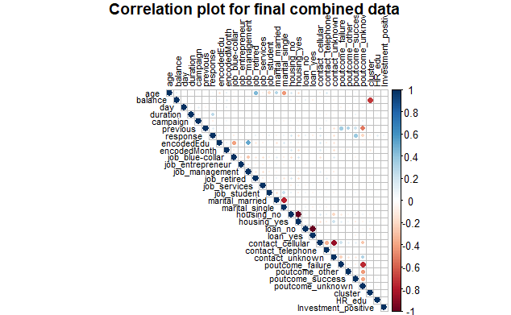

```r
corrplot(cor(finalCombinedData), type = "upper", title = "Correlation plot for final combined data", mar=c(0,0,1,0),
         tl.cex=0.7,
         tl.col = "black")
```

Train and Test Split

```r
# Generate a random number sequence that can be reproduced to verify results.
set.seed(2004)

train1 <- sample.split(Y = finalCombinedData$response, SplitRatio = 0.75)
trainset1 <- subset(finalCombinedData, train1 == T)
testset1 <- subset(finalCombinedData, train1 == F)
summary(trainset1)
```

```
      age           balance            day           duration        campaign        previous
 Min.   :18.00   Min.   : -8019   Min.   : 1.00   Min.   :  0.0   Min.   :1.000   Min.   :  0.0000
 1st Qu.:33.00   1st Qu.:    71   1st Qu.: 8.00   1st Qu.:103.0   1st Qu.:1.000   1st Qu.:  0.0000
 Median :39.00   Median :   442   Median :16.00   Median :172.0   Median :2.000   Median :  0.0000
 Mean   :40.93   Mean   :  1328   Mean   :15.53   Mean   :208.9   Mean   :2.129   Mean   :  0.6026
 3rd Qu.:48.00   3rd Qu.:  1407   3rd Qu.:21.00   3rd Qu.:283.0   3rd Qu.:3.000   3rd Qu.:  0.0000
 Max.   :95.00   Max.   :102127   Max.   :31.00   Max.   :643.0   Max.   :6.000   Max.   :275.0000
    response         encodedEdu     encodedMonth    job_blue-collar  job_entrepreneur  job_management
 Min.   :0.00000   Min.   :1.000   Min.   : 1.000   Min.   :0.0000   Min.   :0.00000   Min.   :0.000
 1st Qu.:0.00000   1st Qu.:2.000   1st Qu.: 5.000   1st Qu.:0.0000   1st Qu.:0.00000   1st Qu.:0.000
 Median :0.00000   Median :2.000   Median : 6.000   Median :0.0000   Median :0.00000   Median :0.000
 Mean   :0.09114   Mean   :2.138   Mean   : 6.099   Mean   :0.2213   Mean   :0.03142   Mean   :0.207
 3rd Qu.:0.00000   3rd Qu.:3.000   3rd Qu.: 8.000   3rd Qu.:0.0000   3rd Qu.:0.00000   3rd Qu.:0.000
 Max.   :1.00000   Max.   :3.000   Max.   :12.000   Max.   :1.0000   Max.   :1.00000   Max.   :1.000
  job_retired       job_services    job_student      marital_married  marital_single     housing_no
 Min.   :0.00000   Min.   :0.000   Min.   :0.00000   Min.   :0.0000   Min.   :0.0000   Min.   :0.0000
 1st Qu.:0.00000   1st Qu.:0.000   1st Qu.:0.00000   1st Qu.:0.0000   1st Qu.:0.0000   1st Qu.:0.0000
 Median :0.00000   Median :0.000   Median :0.00000   Median :1.0000   Median :0.0000   Median :0.0000
 Mean   :0.05065   Mean   :0.092   Mean   :0.02139   Mean   :0.6017   Mean   :0.2851   Mean   :0.4432
 3rd Qu.:0.00000   3rd Qu.:0.000   3rd Qu.:0.00000   3rd Qu.:1.0000   3rd Qu.:1.0000   3rd Qu.:1.0000
 Max.   :1.00000   Max.   :1.000   Max.   :1.00000   Max.   :1.0000   Max.   :1.0000   Max.   :1.0000
  housing_yes        loan_no          loan_yes      contact_cellular contact_telephone contact_unknown
 Min.   :0.0000   Min.   :0.0000   Min.   :0.0000   Min.   :0.000    Min.   :0.00000   Min.   :0.0000
 1st Qu.:0.0000   1st Qu.:1.0000   1st Qu.:0.0000   1st Qu.:0.000    1st Qu.:0.00000   1st Qu.:0.0000
 Median :1.0000   Median :1.0000   Median :0.0000   Median :1.000    Median :0.00000   Median :0.0000
 Mean   :0.5568   Mean   :0.8386   Mean   :0.1614   Mean   :0.652    Mean   :0.06184   Mean   :0.2862
 3rd Qu.:1.0000   3rd Qu.:1.0000   3rd Qu.:0.0000   3rd Qu.:1.000    3rd Qu.:0.00000   3rd Qu.:1.0000
 Max.   :1.0000   Max.   :1.0000   Max.   :1.0000   Max.   :1.000    Max.   :1.00000   Max.   :1.0000
 poutcome_failure poutcome_other    poutcome_success  poutcome_unknown    cluster          HR_edu
 Min.   :0.000    Min.   :0.00000   Min.   :0.00000   Min.   :0.0000   Min.   :1.000   Min.   :1.000
 1st Qu.:0.000    1st Qu.:0.00000   1st Qu.:0.00000   1st Qu.:1.0000   1st Qu.:4.000   1st Qu.:2.000
 Median :0.000    Median :0.00000   Median :0.00000   Median :1.0000   Median :4.000   Median :3.000
 Mean   :0.116    Mean   :0.04216   Mean   :0.03452   Mean   :0.8073   Mean   :3.698   Mean   :2.551
 3rd Qu.:0.000    3rd Qu.:0.00000   3rd Qu.:0.00000   3rd Qu.:1.0000   3rd Qu.:4.000   3rd Qu.:4.000
 Max.   :1.000    Max.   :1.00000   Max.   :1.00000   Max.   :1.0000   Max.   :4.000   Max.   :4.000
 Investment_positive
 Min.   :3.400e-08
 1st Qu.:1.044e-03
 Median :2.025e-03
 Mean   :2.025e-03
 3rd Qu.:3.008e-03
 Max.   :4.000e-03
```

Balance imbalanced dataset using SMOTE

```r
# Count of unique value in the target variable
as.data.frame(table(trainset1$response))
```

| Var1 | Freq |
| --- | --- |
| 0 | 26644 |
| 1 | 2672 |

```r
# Convert the response var from num to factor
trainset1$response = as.factor(trainset1$response)
## Smote : Synthetic Minority Oversampling Technique To Handle Response Imbalancy In Binary Classification
balanced_trainset1 = SMOTE(response~., trainset1, perc.over = 200, k = 5, perc.under = 200, learner = NULL)

as.data.frame(table(balanced_trainset1$response))
```

| Var1 | Freq |
| --- | --- |
| 0 | 10688 |
| 1 | 8016 |

```r
# Convert the response var from num to factor
testset1$response = as.factor(testset1$response)
## Smote : Synthetic Minority Oversampling Technique To Handle Response Imbalancy In Binary Classification
balanced_testset1 = SMOTE(response~., testset1, perc.over = 200, k = 5, perc.under = 200, learner = NULL)

as.data.frame(table(balanced_testset1$response))
```

| Var1 | Freq |
| --- | --- |
| 0 | 3560 |
| 1 | 2670 |

Feature selection on the combined variables

```r
boruta_c <- Boruta(response ~ ., data = balanced_testset1, doTrace = 2, maxRuns=11)
```

```
 1. run of importance source...
 2. run of importance source...
 3. run of importance source...
 4. run of importance source...
 5. run of importance source...
 6. run of importance source...
 7. run of importance source...
 8. run of importance source...
 9. run of importance source...
 10. run of importance source...
```

```r
print(boruta_c)
```

```
Boruta performed 10 iterations in 51.6032 secs.
 No attributes deemed important.
 No attributes deemed unimportant.
 30 tentative attributes left: `job_blue-collar`, age, balance, campaign, cluster and 25 more;
```

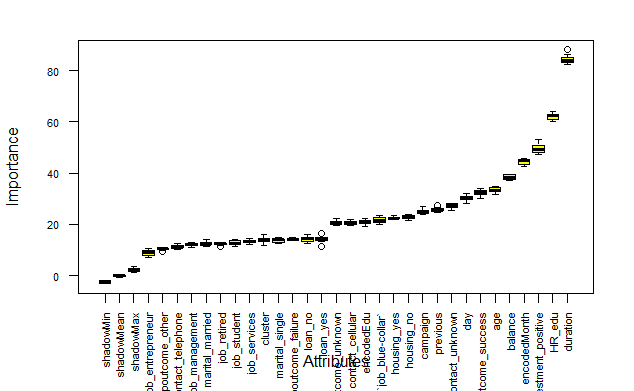

```r
plot(boruta_c, las = 2, cex.axis = 0.7)
```

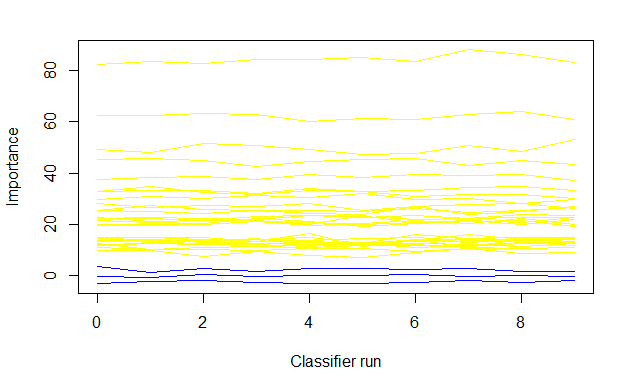

```r
plotImpHistory(boruta_c)
```

```r
bor_c <- TentativeRoughFix(boruta_c)
print(bor_c)
```

```
Boruta performed 10 iterations in 51.6032 secs.
Tentatives roughfixed over the last 10 iterations.
 30 attributes confirmed important: `job_blue-collar`, age, balance, campaign, cluster and 25 more;
 No attributes deemed unimportant.
```

```r
attStats(bor_c)
```

|  | meanImp | medianImp | minImp | maxImp | normHits | decision |
| --- | --- | --- | --- | --- | --- | --- |
| age | 33.27768 | 33.221652 | 31.787040 | 34.60890 | 1 | Confirmed |
| balance | 38.47857 | 38.465114 | 37.061467 | 39.60421 | 1 | Confirmed |
| day | 30.17653 | 30.086443 | 28.172468 | 32.01976 | 1 | Confirmed |
| duration | 84.35947 | 83.908792 | 82.509572 | 88.17189 | 1 | Confirmed |
| campaign | 25.12109 | 25.057682 | 23.867911 | 26.95486 | 1 | Confirmed |
| previous | 25.77991 | 25.514912 | 24.627244 | 27.35835 | 1 | Confirmed |
| encodedEdu | 20.75056 | 21.051191 | 19.101793 | 22.14855 | 1 | Confirmed |
| encodedMonth | 44.58668 | 44.997026 | 42.614404 | 45.84627 | 1 | Confirmed |
| `job_blue-collar` | 21.51553 | 21.377330 | 20.139724 | 23.35855 | 1 | Confirmed |
| job_entrepreneur | 8.89059 | 9.123294 | 7.205508 | 10.64897 | 1 | Confirmed |

[output cut: 20 more lines]

```r
getSelectedAttributes(bor_c, withTentative = F)
```

```
 [1] "age"                 "balance"             "day"                 "duration"
 [5] "campaign"            "previous"            "encodedEdu"          "encodedMonth"
 [9] "`job_blue-collar`"   "job_entrepreneur"    "job_management"      "job_retired"
[13] "job_services"        "job_student"         "marital_married"     "marital_single"
[17] "housing_no"          "housing_yes"         "loan_no"             "loan_yes"
[21] "contact_cellular"    "contact_telephone"   "contact_unknown"     "poutcome_failure"
[25] "poutcome_other"      "poutcome_success"    "poutcome_unknown"    "cluster"
[29] "HR_edu"              "Investment_positive"
```

## XGBoost model with stratified 10 fold cross validation of Operations, HR and Investment data combined

```r
grid_default <- expand.grid(
  nrounds = 100,
  max_depth = 6,
  eta = 0.3,
  gamma = 0,
  colsample_bytree = 1,
  min_child_weight = 1,
  subsample = 1
)

folds=10
cvIndex <- createFolds(factor(balanced_trainset1$response), folds, returnTrain = T) #stratified k fold
train_control <- trainControl(
  index = cvIndex,
  number = folds,
  method = "cv",
  verboseIter = FALSE, # no training log
  allowParallel = TRUE # FALSE for reproducible results
)

xgb_base <- train(
  response~., data=balanced_trainset1,
  trControl = train_control,
  tuneGrid = grid_default,
  method = "xgbTree",
  verbose = TRUE
)

print(xgb_base)
```

```
eXtreme Gradient Boosting

18704 samples
   30 predictor
    2 classes: '0', '1'

No pre-processing
Resampling: Cross-Validated (10 fold)
Summary of sample sizes: 16834, 16833, 16833, 16833, 16834, 16835, ...
Resampling results:

  Accuracy  Kappa
  0.94568   0.8890306

Tuning parameter 'nrounds' was held constant at a value of 100
Tuning parameter 'max_depth' was held
 of 1
Tuning parameter 'min_child_weight' was held constant at a value of 1
Tuning parameter 'subsample'
 was held constant at a value of 1
```

Confusion Matrix and Accuracies

```r
xgb_base.predict.train1 <- predict(xgb_base, newdata = balanced_trainset1, type = "raw")
results <- data.frame(balanced_trainset1, xgb_base.predict.train1)
traintable <- table(xgb_base.predict.train1, balanced_trainset1$response)
traintable
```

```
xgb_base.predict.train1     0     1
                      0 10566   145
                      1   122  7871
```

```r
round(prop.table(traintable),3)
```

```
xgb_base.predict.train1     0     1
                      0 0.565 0.008
                      1 0.007 0.421
```

```r
print("Train Accuracy:")
```

```
[1] "Train Accuracy:"
```

```r
mean(results$xgb_base.predict.train1 == balanced_trainset1$response)
```

```
[1] 0.985725
```

```r
xgb_base.predict.test1 <- predict(xgb_base, newdata = balanced_testset1, type = "raw")
results <- data.frame(balanced_testset1, xgb_base.predict.test1)
testtable <- table(xgb_base.predict.test1, balanced_testset1$response)
testtable
```

```
xgb_base.predict.test1    0    1
                     0 3336  219
                     1  224 2451
```

```r
round(prop.table(testtable),3)
```

```
xgb_base.predict.test1     0     1
                     0 0.535 0.035
                     1 0.036 0.393
```

```r
print("Test Accuracy:")
```

```
[1] "Test Accuracy:"
```

```r
mean(results$xgb_base.predict.test1 == balanced_testset1$response)
```

```
[1] 0.9288925
```

## Hyperparameter tuning on XGBoost to further optimise model done using grid search

```r
nrounds <- 1000
# note to start nrounds from 200, as smaller learning rates result in errors so
# big with lower starting points that they'll mess the scales
tune_grid <- expand.grid(
  nrounds = seq(from = 200, to = nrounds, by = 50),
  eta = c(0.025, 0.05, 0.1, 0.3),
  max_depth = c(2, 3, 4, 5, 6),
  gamma = 0,
  colsample_bytree = 1,
  min_child_weight = 1,
  subsample = 1
)

tune_control <- trainControl(
  method = "cv", # cross-validation
  number = 10, # with n folds
  index = createFolds(balanced_trainset1$response), # fix the folds
  verboseIter = FALSE, # no training log
  allowParallel = TRUE # FALSE for reproducible results
)

xgb_tune <- train(
  response~., data=balanced_trainset1,
  trControl = tune_control,
  tuneGrid = tune_grid,
  method = "xgbTree",
  verbose = TRUE
)
```

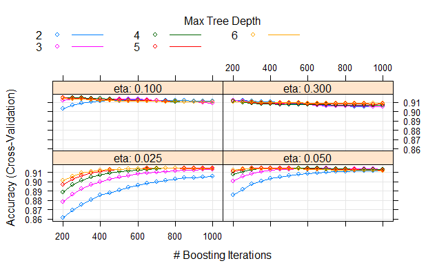

```r
plot(xgb_tune)
```

```r
xgb_tune
```

```
eXtreme Gradient Boosting

18704 samples
   30 predictor
    2 classes: '0', '1'

No pre-processing
Resampling: Cross-Validated (10 fold)
Summary of sample sizes: 1871, 1871, 1871, 1871, 1869, 1870, ...
Resampling results across tuning parameters:

  eta    max_depth  nrounds  Accuracy   Kappa
  0.025  2           200     0.8615506  0.7196102
  0.025  2           250     0.8695702  0.7356143
  0.025  2           300     0.8757246  0.7478694
  0.025  2           350     0.8807562  0.7579378
  0.025  2           400     0.8854790  0.7674002
  0.025  2           450     0.8884076  0.7732410
  0.025  2           500     0.8913957  0.7791991
  0.025  2           550     0.8938432  0.7840691
  0.025  2           600     0.8964689  0.7893298
  0.025  2           650     0.8987085  0.7938277
  0.025  2           700     0.9001105  0.7966305
  0.025  2           750     0.9015481  0.7995109
  0.025  2           800     0.9025520  0.8015129
  0.025  2           850     0.9040253  0.8044625
  0.025  2           900     0.9046906  0.8057872
  0.025  2           950     0.9052728  0.8069486
  0.025  2          1000     0.9060926  0.8085841
  0.025  3           200     0.8783681  0.7534027
  0.025  3           250     0.8862631  0.7692079
  0.025  3           300     0.8926432  0.7819718
  0.025  3           350     0.8966531  0.7899739
  0.025  3           400     0.9000213  0.7967214
  0.025  3           450     0.9028668  0.8024011
  0.025  3           500     0.9051361  0.8069237
  0.025  3           550     0.9069302  0.8105149
  0.025  3           600     0.9084569  0.8135752
  0.025  3           650     0.9093777  0.8153959
  0.025  3           700     0.9103875  0.8174063
```

[output cut: 168 more lines]

```
  0.100  3           650     0.9128707  0.8220236
  0.100  3           700     0.9123183  0.8208978
  0.100  3           750     0.9113559  0.8189223
  0.100  3           800     0.9112430  0.8186900
 [ reached getOption("max.print") -- omitted 140 rows ]

Tuning parameter 'gamma' was held constant at a value of 0
Tuning parameter 'colsample_bytree' was
 held constant at a value of 1
Tuning parameter 'min_child_weight' was held constant at a value of 1

Tuning parameter 'subsample' was held constant at a value of 1
Accuracy was used to select the optimal model using the largest value.
The final values used for the model were nrounds = 300, max_depth = 4, eta = 0.1, gamma = 0, colsample_bytree
 = 1, min_child_weight = 1 and subsample = 1.
```

Final Model Confusion Matrix and Accuracies

```r
xgb_tune.predict.train <- predict(xgb_tune, newdata = balanced_trainset1, type = "raw")
results <- data.frame(balanced_trainset1, xgb_tune.predict.train)
traintable <- table(xgb_tune.predict.train, balanced_trainset1$response)
traintable
```

```
xgb_tune.predict.train     0     1
                     0 10303   391
                     1   385  7625
```

```r
round(prop.table(traintable),2)
```

```
xgb_tune.predict.train    0    1
                     0 0.55 0.02
                     1 0.02 0.41
```

```r
print("Train Accuracy:")
```

```
[1] "Train Accuracy:"
```

```r
mean(results$xgb_tune.predict.train == balanced_trainset1$response)
```

```
[1] 0.9585115
```

```r
xgb_tune.predict.test <- predict(xgb_tune, newdata = balanced_testset1, type = "raw")
results <- data.frame(balanced_testset1, xgb_tune.predict.test)
testtable <- table(xgb_tune.predict.test, balanced_testset1$response)
testtable
```

```
xgb_tune.predict.test    0    1
                    0 3352  217
                    1  208 2453
```

```r
round(prop.table(testtable),2)
```

```
xgb_tune.predict.test    0    1
                    0 0.54 0.03
                    1 0.03 0.39
```

```r
print("Test Accuracy:")
```

```
[1] "Test Accuracy:"
```

```r
mean(results$xgb_tune.predict.test == balanced_testset1$response)
```

```
[1] 0.9317817
```

# Conclusion

An “Oracle” is an intelligent entity capable of providing highly valuable insights and advice. In the same line-of-thought, Oracle was designed to see through and utilise WhiteRock’s technical assets as a whole, to derive unique insights while reducing the cost of labour.

Using the UCI Bank Marketing Dataset as a proof of case for our solution, Oracle, we have proven that Oracle has the abilities to provide data cleaning, data visualisations, significant and relevant insights to an input dataset. Most importantly, Oracle has built a highly optimised machine learning model to produce accurate predictions on client acquisition. This will in turn help asset managers of WhiteRock optimise their client acquisition process by targeting the right customer groups using the most efficient marketing initiative strategy.

In the future, we hope to develop a suite of applications, similar to Athena, which can build upon and further boost the efficiency of Oracle’s performance. Our goal is to provide WhiteRock with an edge against competitors, with a solution that is robust, easy to integrate and adaptable.